# Introducción a R

## Ejemplo

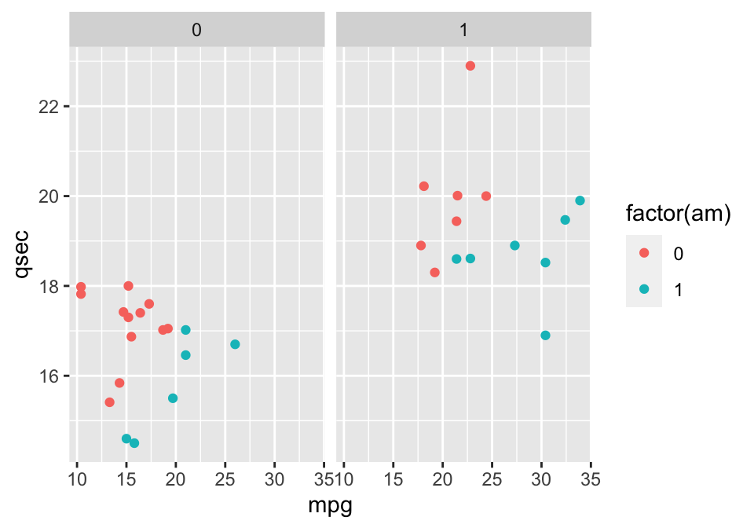

```r
ggplot(data = mtcars) +
  geom_point(aes(mpg,
  qsec, colour = factor(am))) +
  facet_grid(~vs)
```

## Ejemplo

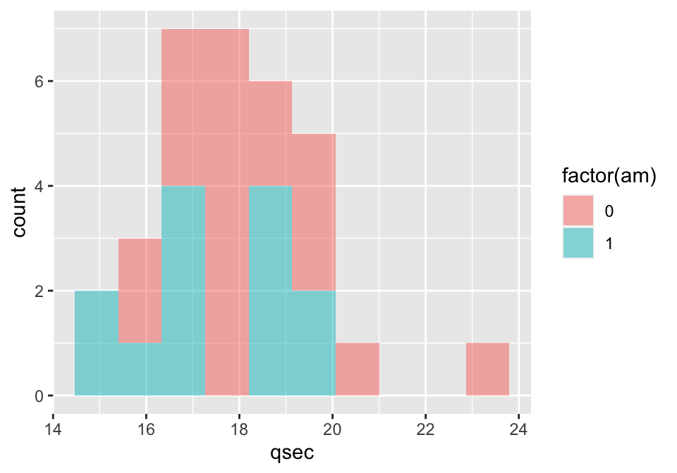

```r
ggplot(data = mtcars) +
 geom_histogram(aes(x=qsec,
fill=factor(am)),bins=10,
position = "stack",alpha = 0.5)
```

## Ejemplo

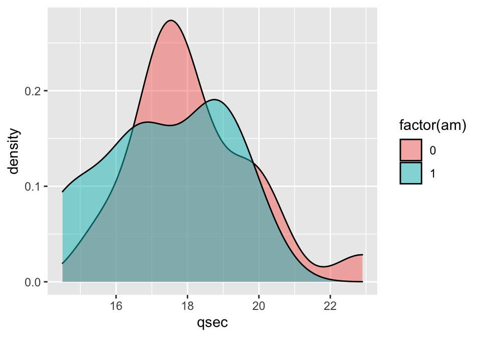

```r
ggplot(data = mtcars) +
  geom_density(aes(x=qsec,
  fill=factor(am)),bins=10,
  position = "identity",alpha = 0.5)
```

## Cargar archivos

## Lectura de datos

R permite una amplia variadad de acceso de archivos:

- Archivos de excel .xls, .xlsx, .csv;
- Archivos de texto plano .txt;
- Archivos de spss .sav;
- Archivos de la web;
- Archivos de bases de datos, etc.

## Directorio de trabajo

- Working directory (wd). Es la dirección donde se almacenan, leen y escriben los archivos utilizados y generados mediante R.
- getwd() permite obtener el wd actual:

```r
getwd()
```

```
## [1] "/Users/yandiracuvero/Desktop/IntroR2022"
```

## Directorio de trabajo

setwd() permite setear un nuevo wd, por ejemplo:

```r
setwd("/Users/yandiracuvero/Desktop/IntroR2022/")
```

## Directorio de trabajo

dir() enlista los nombres de los archivos en el wd actual.

```r
dir()
```

```
##  [1] "coercionR.png"       "combinarR.png"       "comoFunciona.png"
##  [4] "dataFrameR.png"      "elementosDF.png"     "EPN.png"
##  [7] "factorR.png"         "fig01R.png"          "fig02.png"
## [10] "fig03.png"           "fig04.png"           "form11.jpg"
## [13] "hip.jpg"             "IntroduccionR_files" "IntroduccionR.html"
## [16] "IntroduccionR.Rmd"   "leeArchivosR.png"    "nyc.csv"
## [19] "objetosR.png"        "ScriptManana.R"      "TIIE_RUGE_u1"
## [22] "TIIE_RUGE_u2"        "TIIE_RUGE_u3"
```

## ¿Cómo leer archivos en R?

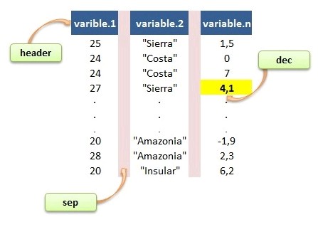

## Archivos .txt

Se requiere leer un archivo en formato txt: archivo.txt.

Se utiliza la función read.table()

Parámetros: - file: nombre del archivo (incluida extensión); - sep: caracter utilizado para separar columnas (variables); - dec: caracter utilizado para decimales; - header: TRUE, si la primera fila contiene los nombres de las columnas. str() describe la estructura de datos.

## Archivo .txt

```r
data_txt <- read.table(file = "archivo.txt",sep = "nt",
dec = ",", header = TRUE)
str(data_txt)
```

## Lectura de archivos .csv

- Se requiere leer un archivo en formato csv: **archivo.csv**
- Se utiliza las función read.csv que presenta por defecto los argumentos:
- sep = “,”,
- dec = “.”,
- header = TRUE

```r
data_csv <- read.csv(file = "archivo.csv")
```

## Ejemplo

```r
nyc <- read.csv(file = "nyc.csv")
head(nyc)
```

```
##   Case          Restaurant Price Food Decor Service East
## 1    1 Daniella Ristorante    43   22    18      20    0
## 2    2  Tello's Ristorante    32   20    19      19    0
## 3    3          Biricchino    34   21    13      18    0
## 4    4             Bottino    41   20    20      17    0
## 5    5          Da Umberto    54   24    19      21    0
## 6    6            Le Madri    52   22    22      21    0
```

## Ejemplo

```r
mean(nyc$Price)
```

```
## [1] 42.69643
```

```r
sd(nyc$Price)
```

```
## [1] 9.292814
```

## Ejemplo

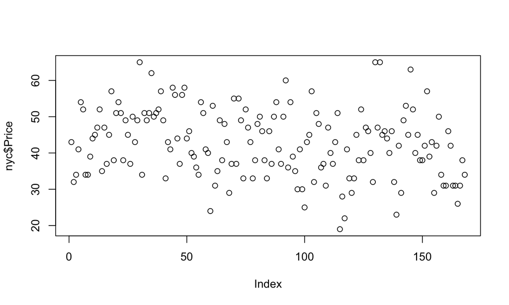

```r
plot(nyc$Price)
```

## Ejemplo

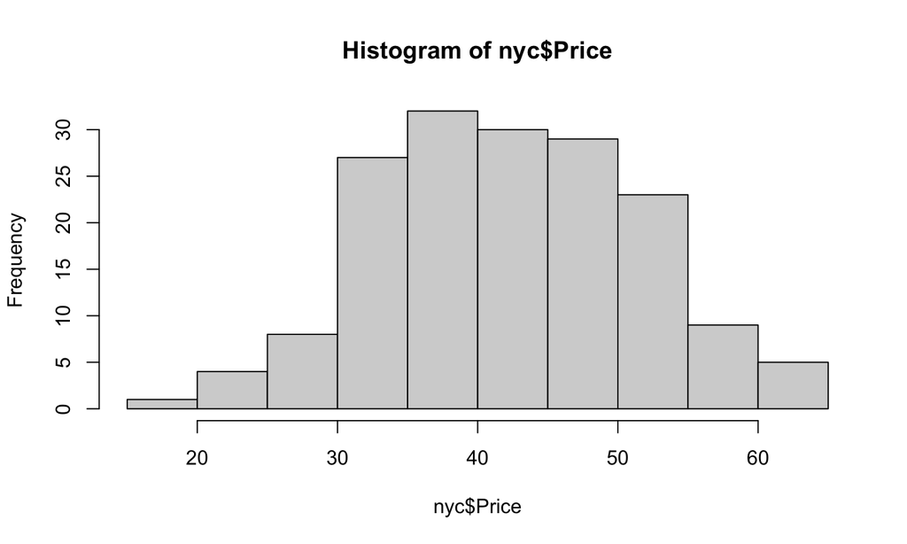

```r
hist(nyc$Price)
```

## Ejemplo

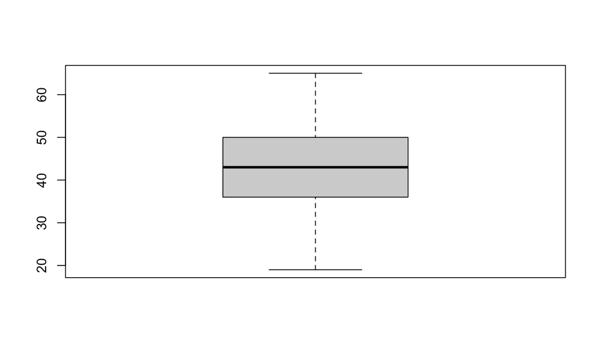

```r
boxplot(nyc$Price)
```